# Выбор локации для скважины

Допустим, вы работаете в добывающей компании «ГлавРосГосНефть». Нужно решить, где бурить новую скважину.

Вам предоставлены пробы нефти в трёх регионах: в каждом 10 000 месторождений, где измерили качество нефти и объём её запасов. Постройте модель машинного обучения, которая поможет определить регион, где добыча принесёт наибольшую прибыль. Проанализируйте возможную прибыль и риски техникой *Bootstrap.*

**Шаги для выбора локации:**

- В избранном регионе ищут месторождения, для каждого определяют значения признаков;
- Строят модель и оценивают объём запасов;
- Выбирают месторождения с самым высокими оценками значений. Количество месторождений зависит от бюджета компании и стоимости разработки одной скважины;
- Прибыль равна суммарной прибыли отобранных месторождений.

**Условия задачи:**

- Для обучения модели подходит только линейная регрессия (остальные — недостаточно предсказуемые).
- При разведке региона исследуют 500 точек, из которых с помощью машинного обучения выбирают 200 лучших для разработки.
- Бюджет на разработку скважин в регионе — 10 млрд рублей.
- При нынешних ценах один баррель сырья приносит 450 рублей дохода. Доход с каждой единицы продукта составляет 450 тыс. рублей, поскольку объём указан в тысячах баррелей.
- После оценки рисков нужно оставить лишь те регионы, в которых вероятность убытков меньше 2.5%. Среди них выбирают регион с наибольшей средней прибылью. Данные синтетические: детали контрактов и характеристики месторождений не разглашаются.

## Стартовые параметры и ввод данных

```python
# Подключаем необходимые библиотеки

import pandas as pd
pd.options.mode.chained_assignment = None # чтобы пофиксить ошибку при масштабировании данных в sklearn

import matplotlib.pyplot as plt
import seaborn as sns
import os
import numpy as np
from scipy import stats as st

from sklearn.model_selection import train_test_split
from sklearn import linear_model
from sklearn.utils import shuffle
from sklearn.linear_model import LinearRegression

import lightgbm as lgb
import sklearn
from sklearn.model_selection import KFold
from sklearn.model_selection import cross_val_score
from sklearn.metrics import (accuracy_score, confusion_matrix, ConfusionMatrixDisplay, f1_score,
                             roc_auc_score, roc_curve, recall_score, precision_score, mean_squared_error)

! pip install phik --quiet
import phik

%matplotlib inline

pd.options.display.float_format = '{:.2f}'.format # отображать 2 знака после запятой
pd.options.display.max_columns = 50 # отображать до 50 колонок
pd.set_option('display.max_colwidth', 130) # увеличиваем максимальную ширину столбца, чтобы видеть больше данных (будут адреса)
```

```python
# Вводим классы для возможности лучшей визуализации
class color:
   BLUE = '\033[94m'
   GREEN = '\033[92m'
   RED = '\033[91m'
   BOLD = '\033[1m'
   UNDERLINE = '\033[4m'
   END = '\033[0m'
```

```python
# Функция загрузки данных из csv.
# На вход функция принимает два варианта пути (локальный/сервер). Загрузка происходит из доступного.
# Нам известно, что колонка с индексом 0 содержит индексы
def import_data(pth_1, pth_2):
    if os.path.exists(pth_1):
        return pd.read_csv(pth_1, sep=',')
    elif os.path.exists(pth_2):
        return pd.read_csv(pth_2, sep=',')
    else:
        print('Загрузка данных неудачно. Нужно проверить, что пошло не так.')
```

```python
# Загружаем данные из 3-х источников
df1 = import_data('/datasets/geo_data_0.csv', r'C:\Python\ml_oil\geo_data_0.csv')
df2 = import_data('/datasets/geo_data_1.csv', r'C:\Python\ml_oil\geo_data_1.csv')
df3 = import_data('/datasets/geo_data_2.csv', r'C:\Python\ml_oil\geo_data_2.csv')
```

```python
#Смотрим результат:
display(df1.head())
display(df2.head())
display(df3.head())
```

|  | id | f0 | f1 | f2 | product |
| --- | --- | --- | --- | --- | --- |
| 0 | txEyH | 0.71 | -0.50 | 1.22 | 105.28 |
| 1 | 2acmU | 1.33 | -0.34 | 4.37 | 73.04 |
| 2 | 409Wp | 1.02 | 0.15 | 1.42 | 85.27 |
| 3 | iJLyR | -0.03 | 0.14 | 2.98 | 168.62 |
| 4 | Xdl7t | 1.99 | 0.16 | 4.75 | 154.04 |

|  | id | f0 | f1 | f2 | product |
| --- | --- | --- | --- | --- | --- |
| 0 | kBEdx | -15.00 | -8.28 | -0.01 | 3.18 |
| 1 | 62mP7 | 14.27 | -3.48 | 1.00 | 26.95 |
| 2 | vyE1P | 6.26 | -5.95 | 5.00 | 134.77 |
| 3 | KcrkZ | -13.08 | -11.51 | 5.00 | 137.95 |
| 4 | AHL4O | 12.70 | -8.15 | 5.00 | 134.77 |

|  | id | f0 | f1 | f2 | product |
| --- | --- | --- | --- | --- | --- |
| 0 | fwXo0 | -1.15 | 0.96 | -0.83 | 27.76 |
| 1 | WJtFt | 0.26 | 0.27 | -2.53 | 56.07 |
| 2 | ovLUW | 0.19 | 0.29 | -5.59 | 62.87 |
| 3 | q6cA6 | 2.24 | -0.55 | 0.93 | 114.57 |
| 4 | WPMUX | -0.52 | 1.72 | 5.90 | 149.60 |

Данные успешно загружены:

- id — уникальный идентификатор скважины;
- f0, f1, f2 — три признака точек (неважно, что они означают, но сами признаки значимы);
- product — объём запасов в скважине (тыс. баррелей).

Для обучения `id` в качестве признака не имеет смысла. `product` - целевой признак.

## Подготовка данных

### Знакомство с данными

#### Фуникция первичного знакомства с данными

```python
# Фуникция первичного знакомства с данными
# Функция, которая сразу выводит всю информацию, принимая на вход название датасета

# Задаем стили seaborn
sns.set_style('darkgrid')
sns.set(rc={"figure.figsize":(15, 5)})

def data_view(data):
    #Сразу приводим названия всех колонок к змеиному регистру.
    data.columns = data.columns. \
                                str.replace(r'([a-z0-9])([A-Z])' , r'\1_\2', regex = True). \
                                str.replace(r'(.)([A-Z][a-z]+)', r'\1_\2', regex = True). \
                                str.replace(r'([a-z0-9])([A-Z])', r'\1_\2', regex = True). \
                                str.replace(r'__([A-Z])', r'_\1', regex = True). \
                                str.replace(r'__([a-z0-9])', r'_\1', regex = True)
    data.columns = data.columns.str.lower()
    print()
    print(color.BLUE + color.BOLD + 'Первые 5 строк данных' + color.END)
    display(data.head()) # Выводим первые 5 строк
    print()
    print(color.BLUE + color.BOLD + 'Информация по датасету' + color.END)
    print()
    display(data.info()) # Выводим инфо по датасету
    print()
    # Уточняем количество пропусков по столбцам. Берем сумму пропусков и процентную долю пропусков
    print(color.BLUE + color.BOLD + 'Пропуски и уникальные значения (без учета пропусков)' + color.END)
    display(pd.concat([data.isna().sum().rename('nan_count'),
                       data.isna().mean().rename('nan_percent'),
                       data.nunique().rename('unique_values')],
                      axis=1).style.format({'nan_percent' : '{:.2%}'}))
    print()
    print(color.BLUE + color.BOLD + 'Дубликаты' + color.END)
    print()
    print('Количество явных дубликатов:', data.duplicated().sum())
    print('Доля явных дубликатов в данных: {:.2%}'.format((data.duplicated().sum())/len(data)))
    print()
    print(color.BLUE + color.BOLD + 'Распределение количественных данных, таблица:' + color.END)
    display(data.describe())
    print()
    # Визуализация распределений
    for param in data.columns[1:5]:
        f, (ax_hist, ax_box) = plt.subplots(2, sharex=True, gridspec_kw={"height_ratios": (.85, .15)})
        sns.histplot(data=data, x=param, kde=True, ax=ax_hist)
        sns.boxplot(data=data, x=param, ax=ax_box)
    plt.show()
```

#### Данные региона №1

```
Первые 5 строк данных
```

|  | id | f0 | f1 | f2 | product |
| --- | --- | --- | --- | --- | --- |
| 0 | txEyH | 0.71 | -0.50 | 1.22 | 105.28 |
| 1 | 2acmU | 1.33 | -0.34 | 4.37 | 73.04 |
| 2 | 409Wp | 1.02 | 0.15 | 1.42 | 85.27 |
| 3 | iJLyR | -0.03 | 0.14 | 2.98 | 168.62 |
| 4 | Xdl7t | 1.99 | 0.16 | 4.75 | 154.04 |

```
Информация по датасету

<class 'pandas.core.frame.DataFrame'>
Int64Index: 99980 entries, 0 to 99999
Data columns (total 5 columns):
 #   Column   Non-Null Count  Dtype
---  ------   --------------  -----
 0   id       99980 non-null  object
 1   f0       99980 non-null  float64
 2   f1       99980 non-null  float64
 3   f2       99980 non-null  float64
 4   product  99980 non-null  float64
dtypes: float64(4), object(1)
memory usage: 4.6+ MB
```

```
None
```

```
Пропуски и уникальные значения (без учета пропусков)
```

|  | nan_count | nan_percent | unique_values |
| --- | --- | --- | --- |
| id | 0 | 0.00% | 99980 |
| f0 | 0 | 0.00% | 99980 |
| f1 | 0 | 0.00% | 99980 |
| f2 | 0 | 0.00% | 99980 |
| product | 0 | 0.00% | 99980 |

```
Дубликаты

Количество явных дубликатов: 0
Доля явных дубликатов в данных: 0.00%

Распределение количественных данных, таблица:
```

|  | f0 | f1 | f2 | product |
| --- | --- | --- | --- | --- |
| count | 99980.00 | 99980.00 | 99980.00 | 99980.00 |
| mean | 0.50 | 0.25 | 2.50 | 92.50 |
| std | 0.87 | 0.50 | 3.25 | 44.29 |
| min | -1.41 | -0.85 | -12.09 | 0.00 |
| 25% | -0.07 | -0.20 | 0.29 | 56.50 |
| 50% | 0.50 | 0.25 | 2.52 | 91.85 |
| 75% | 1.07 | 0.70 | 4.71 | 128.56 |
| max | 2.36 | 1.34 | 16.00 | 185.36 |

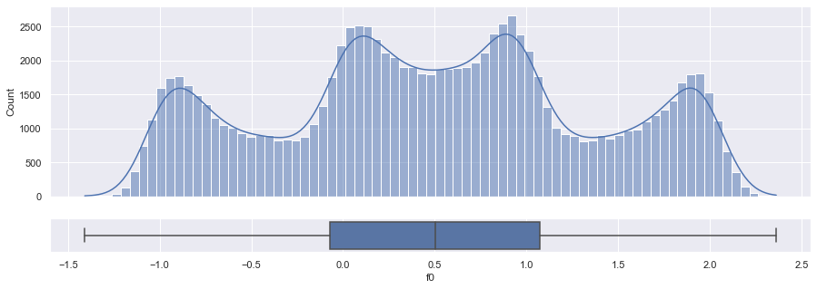

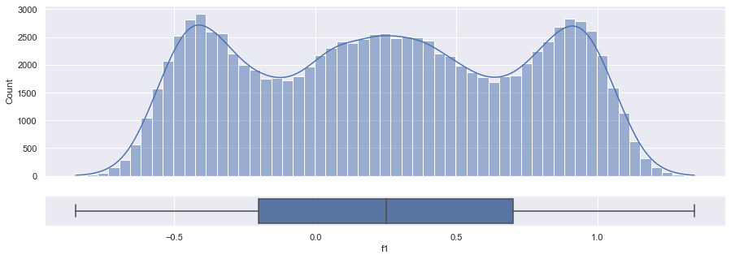

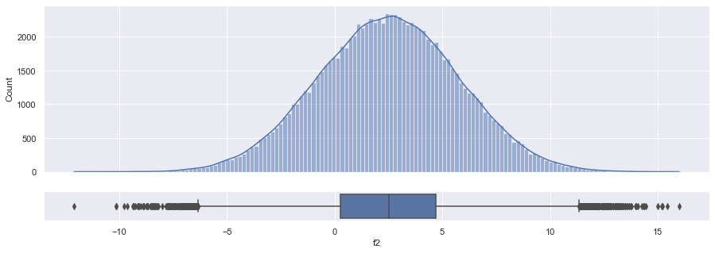

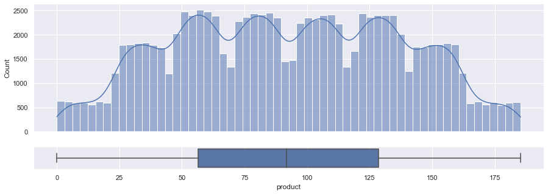

```python
# Используем функцию data_view для знакомства с загруженными данными
data_view(df1)
```

- Особых проблем в данных нет. Нет пропусков или явных дублей.
- Есть неуникальные id в количестве 10шт. Необходимо подробнее рассмотреть этот момент.
- Признаки f0, f1, f2 имеют похожие разбросы значений. Стандартное отклонение небольшое. Очень похоже на то, что это уже масштабированные признаки. f2 нормально распределен, в признаках f0 и f1 есть несколько характерных пиков. В целом поблем с данными нет.

Посмотрим данные с дублированными id

```python
# Сохраняем список неуникальных id в переменную
dubl_id = df1.loc[df1.duplicated(['id']), 'id'].unique()
# Смотрим значения
t = df1.loc[df1['id'].isin(dubl_id)].sort_values('id')
display(t)
print(color.BLUE + color.BOLD + 'Количество записей с неункальными id:' + color.END, len(t))
```

|  | id | f0 | f1 | f2 | product |
| --- | --- | --- | --- | --- | --- |
| 66136 | 74z30 | 1.08 | -0.31 | 6.99 | 127.64 |
| 64022 | 74z30 | 0.74 | 0.46 | 5.15 | 140.77 |
| 51970 | A5aEY | -0.18 | 0.94 | -2.09 | 33.02 |
| 3389 | A5aEY | -0.04 | 0.16 | 0.21 | 89.25 |
| 69163 | AGS9W | -0.93 | 0.12 | -3.66 | 19.23 |
| 42529 | AGS9W | 1.45 | -0.48 | 0.68 | 126.37 |
| 931 | HZww2 | 0.76 | 0.37 | 1.86 | 30.68 |
| 7530 | HZww2 | 1.06 | -0.37 | 10.43 | 158.83 |
| 63593 | QcMuo | 0.64 | -0.47 | 0.86 | 64.58 |
| 1949 | QcMuo | 0.51 | -0.32 | -2.22 | 75.50 |
| 75715 | Tdehs | 0.11 | 0.43 | 3.22 | 60.96 |
| 21426 | Tdehs | 0.83 | 0.30 | -0.05 | 96.04 |
| 92341 | TtcGQ | 0.11 | 1.02 | 0.91 | 101.32 |
| 60140 | TtcGQ | 0.57 | -0.10 | 6.44 | 85.35 |
| 89582 | bsk9y | 0.40 | -0.40 | 10.12 | 163.43 |
| 97785 | bsk9y | 0.38 | 0.01 | 0.16 | 160.64 |
| 41724 | bxg6G | -0.82 | 0.55 | 3.63 | 93.01 |
| 1364 | bxg6G | 0.41 | 0.86 | -3.65 | 73.60 |
| 16633 | fiKDv | 0.16 | 1.03 | 5.59 | 95.82 |
| 90815 | fiKDv | 0.05 | 0.84 | 6.39 | 137.35 |

```
Количество записей с неункальными id: 20
```

Мы видим, что для каких-то вышек данные представлены дважды. Возможно это ошибка или уточненные данные. В реальности мы бы уточнили этот момент у заказчика, но в проекте такой возможности нет. Данных ничтожно мало. Просто удалим спорные.

```python
df1 = df1.loc[~df1['id'].isin(dubl_id)]
df1.info()
```

```
<class 'pandas.core.frame.DataFrame'>
Int64Index: 99980 entries, 0 to 99999
Data columns (total 5 columns):
 #   Column   Non-Null Count  Dtype
---  ------   --------------  -----
 0   id       99980 non-null  object
 1   f0       99980 non-null  float64
 2   f1       99980 non-null  float64
 3   f2       99980 non-null  float64
 4   product  99980 non-null  float64
dtypes: float64(4), object(1)
memory usage: 4.6+ MB
```

Данные df1 подготовлены к работе. Количество записей = 99 980.

#### Данные региона №2

```
Первые 5 строк данных
```

|  | id | f0 | f1 | f2 | product |
| --- | --- | --- | --- | --- | --- |
| 0 | kBEdx | -15.00 | -8.28 | -0.01 | 3.18 |
| 1 | 62mP7 | 14.27 | -3.48 | 1.00 | 26.95 |
| 2 | vyE1P | 6.26 | -5.95 | 5.00 | 134.77 |
| 3 | KcrkZ | -13.08 | -11.51 | 5.00 | 137.95 |
| 4 | AHL4O | 12.70 | -8.15 | 5.00 | 134.77 |

```
Информация по датасету

<class 'pandas.core.frame.DataFrame'>
Int64Index: 99992 entries, 0 to 99999
Data columns (total 5 columns):
 #   Column   Non-Null Count  Dtype
---  ------   --------------  -----
 0   id       99992 non-null  object
 1   f0       99992 non-null  float64
 2   f1       99992 non-null  float64
 3   f2       99992 non-null  float64
 4   product  99992 non-null  float64
dtypes: float64(4), object(1)
memory usage: 4.6+ MB
```

```
None
```

```
Пропуски и уникальные значения (без учета пропусков)
```

|  | nan_count | nan_percent | unique_values |
| --- | --- | --- | --- |
| id | 0 | 0.00% | 99992 |
| f0 | 0 | 0.00% | 99992 |
| f1 | 0 | 0.00% | 99992 |
| f2 | 0 | 0.00% | 99992 |
| product | 0 | 0.00% | 12 |

```
Дубликаты

Количество явных дубликатов: 0
Доля явных дубликатов в данных: 0.00%

Распределение количественных данных, таблица:
```

|  | f0 | f1 | f2 | product |
| --- | --- | --- | --- | --- |
| count | 99992.00 | 99992.00 | 99992.00 | 99992.00 |
| mean | 1.14 | -4.80 | 2.49 | 68.82 |
| std | 8.97 | 5.12 | 1.70 | 45.94 |
| min | -31.61 | -26.36 | -0.02 | 0.00 |
| 25% | -6.30 | -8.27 | 1.00 | 26.95 |
| 50% | 1.15 | -4.81 | 2.01 | 57.09 |
| 75% | 8.62 | -1.33 | 4.00 | 107.81 |
| max | 29.42 | 18.73 | 5.02 | 137.95 |

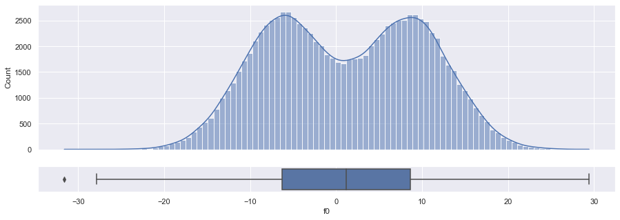

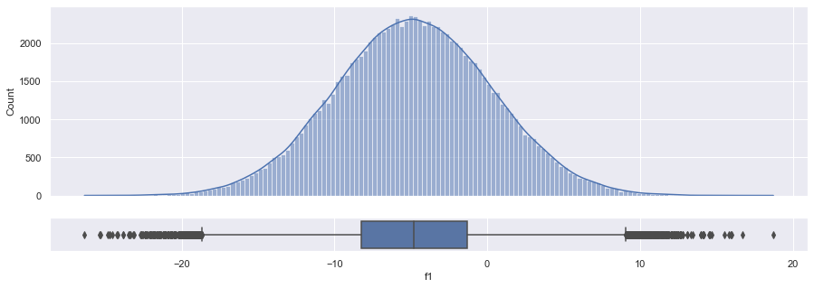

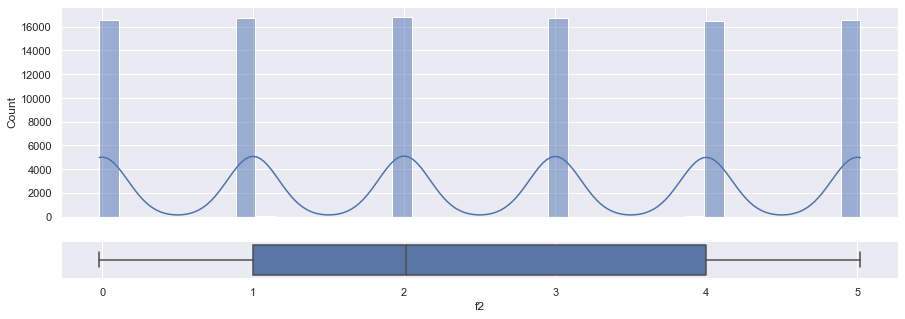

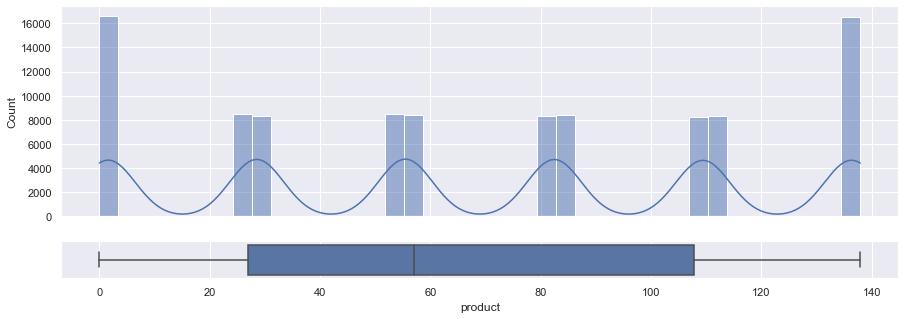

```python
# Используем функцию data_view для знакомства с загруженными данными
data_view(df2)
```

- Нет пропусков или явных дублей.
- В целевом признаке product всего 12 уникальных значений из 100 тыс. записей. Необходимо подробный анализ.
- Есть неуникальные id в количестве 4шт. Необходимо подробнее рассмотреть этот момент.
- Признаки f0, f1 имеют похожие разбросы значений. Стандартное отклонение небольшое. Очень похоже на то, что это уже масштабированные признаки. f1 нормально распределен, в признаке f0 есть несколько характерных пиков. В признаке f2 кол-во уникальных значений 100 тыс. Однако все эти значения распределены весьма дискретно по ряду диапазонов. Необходим более подробный анализ.

Посмотрим данные с дублированными id

```python
# Сохраняем список неуникальных id в переменную
dubl_id = df2.loc[df2.duplicated(['id']), 'id'].unique()
# Смотрим значения
t = df2.loc[df2['id'].isin(dubl_id)].sort_values('id')
display(t)
print(color.BLUE + color.BOLD + 'Количество записей с неункальными id:' + color.END, len(t))
```

|  | id | f0 | f1 | f2 | product |
| --- | --- | --- | --- | --- | --- |
| 5849 | 5ltQ6 | -3.44 | -12.30 | 2.00 | 57.09 |
| 84461 | 5ltQ6 | 18.21 | 2.19 | 3.99 | 107.81 |
| 1305 | LHZR0 | 11.17 | -1.95 | 3.00 | 80.86 |
| 41906 | LHZR0 | -8.99 | -4.29 | 2.01 | 57.09 |
| 2721 | bfPNe | -9.49 | -5.46 | 4.01 | 110.99 |
| 82178 | bfPNe | -6.20 | -4.82 | 3.00 | 84.04 |
| 47591 | wt4Uk | -9.09 | -8.11 | -0.00 | 3.18 |
| 82873 | wt4Uk | 10.26 | -9.38 | 4.99 | 134.77 |

```
Количество записей с неункальными id: 8
```

По аналогии с 1 регионом мы видим, что для каких-то вышек данные представлены дважды. Данных ничтожно мало. Просто удалим спорные.

```python
df2 = df2.loc[~df2['id'].isin(dubl_id)]
df2.info()
```

```
<class 'pandas.core.frame.DataFrame'>
Int64Index: 99992 entries, 0 to 99999
Data columns (total 5 columns):
 #   Column   Non-Null Count  Dtype
---  ------   --------------  -----
 0   id       99992 non-null  object
 1   f0       99992 non-null  float64
 2   f1       99992 non-null  float64
 3   f2       99992 non-null  float64
 4   product  99992 non-null  float64
dtypes: float64(4), object(1)
memory usage: 4.6+ MB
```

Посмотрим подробнее значения `products`:

```python
# Сохраняем список неуникальных id в переменную
df2['product'].value_counts()
```

```
53.91     8472
26.95     8468
84.04     8430
57.09     8388
3.18      8336
80.86     8319
30.13     8306
134.77    8303
110.99    8302
0.00      8235
137.95    8233
107.81    8200
Name: product, dtype: int64
```

```python
# Смотрим распределение значений по 12 уникальным значениям product
print()
print(color.BLUE + color.BOLD + 'Hаспределение значений по 12 уникальным значениям product' + color.END)
display(pd.concat([df2['product'].value_counts().rename('count_of_values'),
                    df2['product'].value_counts(normalize=True).rename('percent_of_values')],
                    axis=1).style.format({'percent_of_values' : '{:.2%}'}))
```

```
Hаспределение значений по 12 уникальным значениям product
```

|  | count_of_values | percent_of_values |
| --- | --- | --- |
| 53.90652206307938 | 8472 | 8.47% |
| 26.95326103153969 | 8468 | 8.47% |
| 84.03888567782631 | 8430 | 8.43% |
| 57.08562464628662 | 8388 | 8.39% |
| 3.179102583207246 | 8336 | 8.34% |
| 80.85978309461906 | 8319 | 8.32% |
| 30.132363614746943 | 8306 | 8.31% |
| 134.76630515769844 | 8303 | 8.30% |
| 110.992146709366 | 8302 | 8.30% |
| 0.0 | 8235 | 8.24% |
| 137.94540774090564 | 8233 | 8.23% |
| 107.81304412615876 | 8200 | 8.20% |

Вы видим достаточно странную картину: Данные практически равномерно распределены по 12 уникальным значениям product. Такое впечатление, что эти данные просто взяты равномерно по каким-то 12 категориям табличных значений. Или это синтетические учебные данные? Возможно именно с этим связана дискретность признака f2, который, вероятно, уникализирован в небольшом пределе рандомно.

Однако у нас нет оснований не доверять этим данным. Принимаем их к изучению.

#### Данные региона №3

```
Первые 5 строк данных
```

|  | id | f0 | f1 | f2 | product |
| --- | --- | --- | --- | --- | --- |
| 0 | fwXo0 | -1.15 | 0.96 | -0.83 | 27.76 |
| 1 | WJtFt | 0.26 | 0.27 | -2.53 | 56.07 |
| 2 | ovLUW | 0.19 | 0.29 | -5.59 | 62.87 |
| 3 | q6cA6 | 2.24 | -0.55 | 0.93 | 114.57 |
| 4 | WPMUX | -0.52 | 1.72 | 5.90 | 149.60 |

```
Информация по датасету

<class 'pandas.core.frame.DataFrame'>
Int64Index: 99992 entries, 0 to 99999
Data columns (total 5 columns):
 #   Column   Non-Null Count  Dtype
---  ------   --------------  -----
 0   id       99992 non-null  object
 1   f0       99992 non-null  float64
 2   f1       99992 non-null  float64
 3   f2       99992 non-null  float64
 4   product  99992 non-null  float64
dtypes: float64(4), object(1)
memory usage: 4.6+ MB
```

```
None
```

```
Пропуски и уникальные значения (без учета пропусков)
```

|  | nan_count | nan_percent | unique_values |
| --- | --- | --- | --- |
| id | 0 | 0.00% | 99992 |
| f0 | 0 | 0.00% | 99992 |
| f1 | 0 | 0.00% | 99992 |
| f2 | 0 | 0.00% | 99992 |
| product | 0 | 0.00% | 99992 |

```
Дубликаты

Количество явных дубликатов: 0
Доля явных дубликатов в данных: 0.00%

Распределение количественных данных, таблица:
```

|  | f0 | f1 | f2 | product |
| --- | --- | --- | --- | --- |
| count | 99992.00 | 99992.00 | 99992.00 | 99992.00 |
| mean | 0.00 | -0.00 | 2.50 | 95.00 |
| std | 1.73 | 1.73 | 3.47 | 44.75 |
| min | -8.76 | -7.08 | -11.97 | 0.00 |
| 25% | -1.16 | -1.17 | 0.13 | 59.45 |
| 50% | 0.01 | -0.01 | 2.48 | 94.93 |
| 75% | 1.16 | 1.16 | 4.86 | 130.59 |
| max | 7.24 | 7.84 | 16.74 | 190.03 |

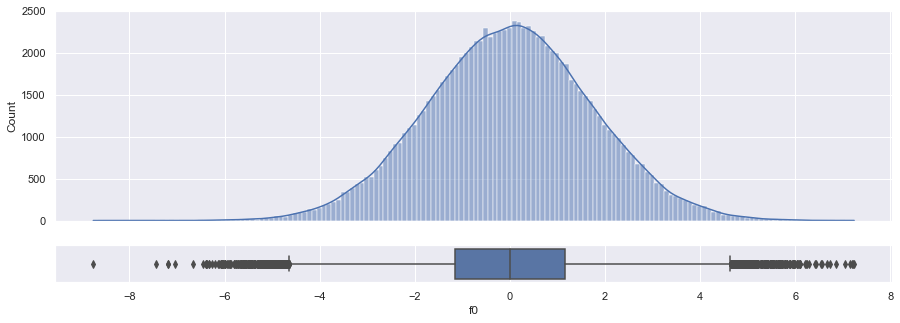

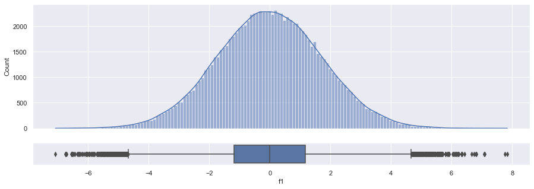

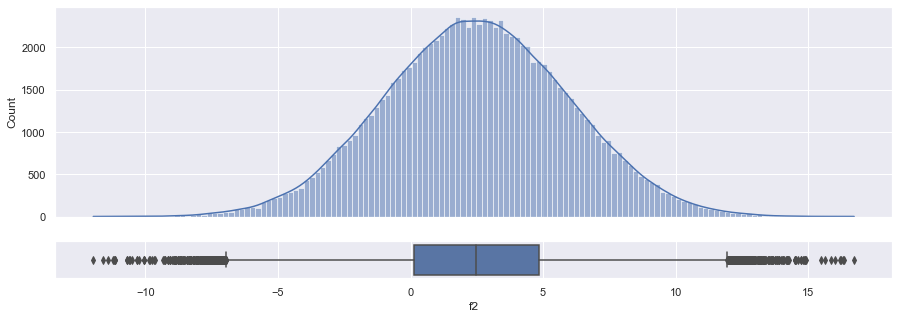

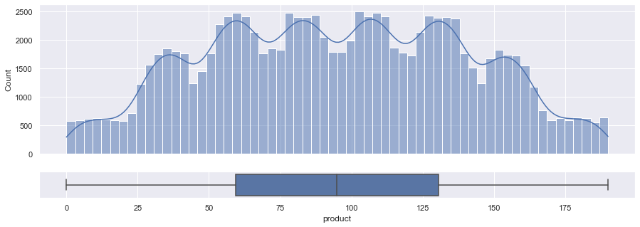

```python
# Используем функцию data_view для знакомства с загруженными данными
data_view(df3)
```

- Данные почти идеальны, распределение всех признаков стремится к нормальному. Нет пропусков или явных дублей.
- Есть неуникальные id в количестве 4шт. Необходимо подробнее рассмотреть этот момент.
- Признаки f0, f1, f2 имеют похожие разбросы значений. Стандартное отклонение небольшое. В целом поблем с данными нет.

Посмотрим данные с дублированными id

```python
# Сохраняем список неуникальных id в переменную
dubl_id = df3.loc[df3.duplicated(['id']), 'id'].unique()
# Смотрим значения
t = df3.loc[df3['id'].isin(dubl_id)].sort_values('id')
display(t)
print(color.BLUE + color.BOLD + 'Количество записей с неункальными id:' + color.END, len(t))
```

|  | id | f0 | f1 | f2 | product |
| --- | --- | --- | --- | --- | --- |
| 45404 | KUPhW | 0.23 | -1.70 | 4.99 | 11.72 |
| 55967 | KUPhW | 1.21 | 3.18 | 5.54 | 132.83 |
| 11449 | VF7Jo | 2.12 | -0.86 | 5.75 | 181.72 |
| 49564 | VF7Jo | -0.88 | 0.56 | 0.72 | 136.23 |
| 44378 | Vcm5J | -1.23 | -2.44 | 1.22 | 137.97 |
| 95090 | Vcm5J | 2.59 | 1.99 | 2.48 | 92.33 |
| 28039 | xCHr8 | 1.63 | 0.37 | -2.38 | 6.12 |
| 43233 | xCHr8 | -0.85 | 2.10 | 5.60 | 184.39 |

```
Количество записей с неункальными id: 8
```

По аналогии с 1 и 2 регионами мы видим, что для каких-то вышек данные представлены дважды. Данных ничтожно мало. Просто удалим спорные.

```python
df3 = df3.loc[~df3['id'].isin(dubl_id)]
df3.info()
```

```
<class 'pandas.core.frame.DataFrame'>
Int64Index: 99992 entries, 0 to 99999
Data columns (total 5 columns):
 #   Column   Non-Null Count  Dtype
---  ------   --------------  -----
 0   id       99992 non-null  object
 1   f0       99992 non-null  float64
 2   f1       99992 non-null  float64
 3   f2       99992 non-null  float64
 4   product  99992 non-null  float64
dtypes: float64(4), object(1)
memory usage: 4.6+ MB
```

### Вывод по разделу

Представленные данные высокого качества и не имеют особых проблем. Признаки для обучающей выборки имеют схожий масштаб.

Во втором регионе данные практически равномерно распределены по 12 уникальным значениям product. Такое впечатление, что эти данные просто взяты равномерно по каким-то 12 категориям табличных значений. Возможно именно с этим связана дискретность признака f2, который, вероятно, уникализирован в небольшом пределе рандомно.

## Подготовка к обучению

### Оценка корреляции признаков по регионам

До начала обучения попытаем проследить линейную и нелинейную корреляции между признаками. Начнем с линейной корреляции Пирсона:

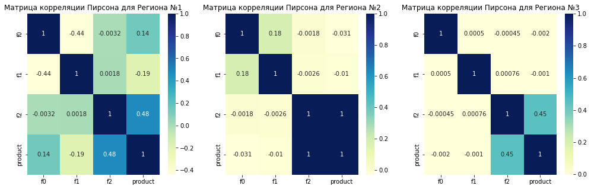

```python
# Определяем индексы корреляции Пирсона и записываем в переменные для каждого региона
corr_overview1 = df1[['f0', 'f1', 'f2', 'product']].corr()
corr_overview2 = df2[['f0', 'f1', 'f2', 'product']].corr()
corr_overview3 = df3[['f0', 'f1', 'f2', 'product']].corr()
# Визуализируем взаимосвязи
plt.figure(figsize=(17,5))
sns.heatmap(corr_overview1, annot=True, cmap="YlGnBu", ax=plt.subplot(1, 3, 1))
plt.title('Матрица корреляции Пирсона для Региона №1')
sns.heatmap(corr_overview2, annot=True, cmap="YlGnBu", ax=plt.subplot(1, 3, 2))
plt.title('Матрица корреляции Пирсона для Региона №2')
sns.heatmap(corr_overview3, annot=True, cmap="YlGnBu", ax=plt.subplot(1, 3, 3))
plt.title('Матрица корреляции Пирсона для Региона №3')
plt.show()
```

- Мы видим, что в различных регионах признаки по-разному коррелируют с целевым. В регионах 1 и 3 картина схожая. Разница только в том, что в регионе 1 есть слабая линейная коррелация с признаками f0 и f1, а в регионе 3 ее практически нет.
- В регионе 2 картина сильно отличается. Там практически 100% линейная корреляция с признаком f2. Опять же - очень похоже на подбор параметров по справочнику.

Хотя мы обучаем модель линейной регрессии, все же посмотрим наличие нелинейной корреляции:

```
interval columns not set, guessing: ['f0', 'f1', 'f2', 'product']
interval columns not set, guessing: ['f0', 'f1', 'f2', 'product']
interval columns not set, guessing: ['f0', 'f1', 'f2', 'product']
```

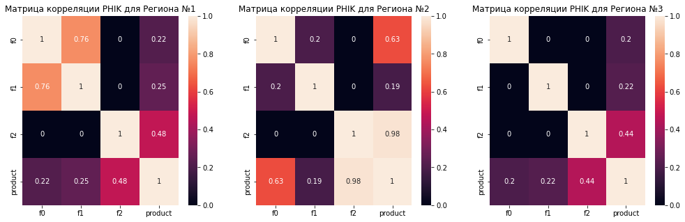

```python
# Определяем индексы нелинейной корреляции и записываем в переменные для каждого региона
phik_overview1 = df1[['f0', 'f1', 'f2', 'product']].phik_matrix()
phik_overview2 = df2[['f0', 'f1', 'f2', 'product']].phik_matrix()
phik_overview3 = df3[['f0', 'f1', 'f2', 'product']].phik_matrix()
# Визуализируем взаимосвязи
plt.figure(figsize=(17,5))
sns.heatmap(phik_overview1, annot=True, ax=plt.subplot(1, 3, 1))
plt.title('Матрица корреляции PHIK для Региона №1')
sns.heatmap(phik_overview2, annot=True, ax=plt.subplot(1, 3, 2))
plt.title('Матрица корреляции PHIK для Региона №2')
sns.heatmap(phik_overview3, annot=True, ax=plt.subplot(1, 3, 3))
plt.title('Матрица корреляции PHIK для Региона №3')
plt.show()
```

- Картина нелинейной корреляции по аналогии с линейной в регионах 1 и 3 по целевому признаку очень похожа. Регион 2 сильно выбивается. Снова крайне высокая корреляция по признаку f2. Так же в регионе 2 есть высокая нелинейная корреляция целевого признака и f0.
- PHIK выявил высокую нелинейную корреляцию между признаками f0 и f1 в регионе 1.

### Разделение на train, valid

По условию задачи нам необходимо разбить данные только на тестовую и валидационную выборки. От модели требуется сделать такие предсказания, которые укрупненно помогут выбрать регион для бурения. Выбор линейной регрессии намекает, что излишняя точность не требуется. Разобьем данные в соотношении 3:1.

Размеры тестового и валидационного наборов равны:

- обучающая выборка `75%`
- валидационная выборка `25%`

Разделим выборки методом train_test_split. Изначальные выборки у нас достаточного размера - 100 тыс. строк.

```python
# Проводим деление на обучающую и валидационную выборки для региона 1
features1 = df1.drop(['id', 'product'],axis=1) # отбираем признаки за исключением целевого
target1 = df1['product'] # извлекаем целевой признак
# С помощью train_split_test отбираем данные для обучающей и валидационной выборки
features_train_1, features_valid_1, target_train_1, target_valid_1 = train_test_split(
    features1, target1, test_size=.25, random_state=42) # отделяем 25% данных для валидационной выборки

# Проводим деление на обучающую и валидационную выборки для региона 2
features2 = df2.drop(['id', 'product'],axis=1) # отбираем признаки за исключением целевого
target2 = df2['product'] # извлекаем целевой признак
# С помощью train_split_test отбираем данные для обучающей и валидационной выборки
features_train_2, features_valid_2, target_train_2, target_valid_2 = train_test_split(
    features2, target2, test_size=.25, random_state=42) # отделяем 25% данных для валидационной выборки

# Проводим деление на обучающую и валидационную выборки для региона 3
features3 = df3.drop(['id', 'product'],axis=1) # отбираем признаки за исключением целевого
target3 = df3['product'] # извлекаем целевой признак
# С помощью train_split_test отбираем данные для обучающей и валидационной выборки
features_train_3, features_valid_3, target_train_3, target_valid_3 = train_test_split(
    features3, target3, test_size=.25, random_state=42) # отделяем 25% данных для валидационной выборки
```

Проверяем себя после разбиения:

```python
def len_test(df, train, valid, num):
    print()
    print('Размер валидационной выборки региона', num, '== {:.0%}'.format(len(valid)/len(df)))
    print()
    print(color.BLUE + color.BOLD + 'Количество строк в изначальном датафрейме в регионе', num + color.END, '==', len(df))
    print(color.GREEN + color.BOLD +
          'Количество строк суммарно в обучающей, валидационной и тестовой выборках =='+ color.END,
          len(train)+len(valid))
```

```python
len_test(df1, features_train_1, features_valid_1, '1')
```

```
Размер валидационной выборки региона 1 == 25%

Количество строк в изначальном датафрейме в регионе 1 == 99980
Количество строк суммарно в обучающей, валидационной и тестовой выборках == 99980
```

```python
len_test(df2, features_train_2, features_valid_2, '2')
```

```
Размер валидационной выборки региона 2 == 25%

Количество строк в изначальном датафрейме в регионе 2 == 99992
Количество строк суммарно в обучающей, валидационной и тестовой выборках == 99992
```

```python
len_test(df3, features_train_3, features_valid_3, '3')
```

```
Размер валидационной выборки региона 3 == 25%

Количество строк в изначальном датафрейме в регионе 3 == 99992
Количество строк суммарно в обучающей, валидационной и тестовой выборках == 99992
```

Разделение успешно. Можно двигаться дальше.

## Обучение и проверка модели

Так как у нас 3 региона, и нампридется выполнять одинаковые операции - пишем функцию.

```python
'''
    Функция принимает на вход стандартные параметры:

        features_train - обучающие фичи
        target_train - обучающий таргет
        features_valid - валидационные фичи
        target_valid - таргет валидации
        num - число, которое используется при выводе параметров для маркировки региона

    Функция обучает модель  линейной регресси, а так же:
        1. считает и выводит средний скор r2 на CV
        2. считает и выводит RMSE
        3. считает и выводит средний запас сырья по реальным таргетам на валидационной выборке
        4. считает и выводит средний запас сырья по предсказанному на валидационной выборке

    Функция возвращает:
        1. Обученную модель
        2. Предсказания на валидационной выборке
        3. Таргеты валидационной выборки со сброшенными индексами
        4. Датафрейм, который в котором сопоставлены реальные и предсказанные значения

'''

def build_model(features_train, target_train, features_valid, target_valid, num):
    model = LinearRegression() # инициализируем модель LinearRegression
    model.fit(features_train, target_train) # обучаем модель на тренировочной выборке
    predictions_valid = model.predict(features_valid) # получаем предсказания модели на валидационной выборке

    # Определяем фолды для CV
    folds = KFold(n_splits = 5, shuffle = True, random_state = 42)

    # вычисляем средний скор на кросс-валидации
    scores = cross_val_score(model, features_train, target_train, scoring='r2', cv=folds)
    # вычисляем RMSE
    result = mean_squared_error(target_valid, predictions_valid)**.5 # значение метрики RMSE на валидационной выборке
    # Выводим информацию
    print()
    print(color.BLUE + 'Скор R2 модели региона {:.0f} при кросс-валидации =='.format(num)
          + color.END, scores.mean())
    print(color.BLUE + 'RMSE модели региона {:.0f} на валидационной выборке =='.format(num)
          + color.END, result)
    print()
    print(color.BLUE+ 'Cредний запас предсказанного сырья региона {:.0f} =='.format(num)
          + color.END, predictions_valid.mean())

    # Собираем реальные таргеты на валидации и предсказанные в один датафрейм
    result_model = target_valid.reset_index()
    result_model['product_pred'] = predictions_valid
    result_model = result_model.drop(['index'],axis=1)

    # Выводим 5 случайных строк собранного датафрейма
    print('\n')
    print(color.BOLD + 'Данные по реальным и предсказанными значениями на валидации:' + color.END)
    display(result_model.sample(5))
    display(result_model.describe())
    print()

    return model, pd.Series(predictions_valid), target_valid.reset_index(drop=True), result_model
```

### Регион 1

```python
# С помощью функции обучаем модель, сохраняем данные, смотрим параметры
model_1, pred_1, targets_1, results_1 = build_model(features_train_1, target_train_1, features_valid_1, target_valid_1, 1)
```

```
Скор R2 модели региона 1 при кросс-валидации == 0.2766934497197687
RMSE модели региона 1 на валидационной выборке == 37.76114714593895

Cредний запас предсказанного сырья региона 1 == 92.2865385223536


Данные по реальным и предсказанными значениями на валидации:
```

|  | product | product_pred |
| --- | --- | --- |
| 726 | 107.53 | 71.28 |
| 6861 | 47.07 | 85.42 |
| 9865 | 150.67 | 85.98 |
| 22517 | 152.98 | 93.13 |
| 3875 | 119.11 | 86.60 |

|  | product | product_pred |
| --- | --- | --- |
| count | 24995.00 | 24995.00 |
| mean | 92.37 | 92.29 |
| std | 44.26 | 23.12 |
| min | 0.00 | -10.13 |
| 25% | 56.55 | 76.53 |
| 50% | 90.79 | 92.28 |
| 75% | 128.46 | 108.01 |
| max | 185.36 | 185.82 |

По региону 1 мы получили достаточно низкий показатель R2 примерно 0,28. Такой коэффичиент детерминации означает, что имеющиеся у нас значения неслишком хорошо коррелируют с нашей линей моделью. Это в принципе подтверждает сделанные нами ранее выводы.

RMSE 37,76 так же достаточно большой для полученного среднего 92.29. Однако среднее значение предсказано достаточно точно.

### Регион 2

```python
# С помощью функции обучаем модель, сохраняем данные, смотрим параметры
model_2, pred_2, targets_2, results_2 = build_model(features_train_2, target_train_2, features_valid_2, target_valid_2, 2)
```

```
Скор R2 модели региона 2 при кросс-валидации == 0.9996248766491622
RMSE модели региона 2 на валидационной выборке == 0.892863589877732

Cредний запас предсказанного сырья региона 2 == 69.16894101447984


Данные по реальным и предсказанными значениями на валидации:
```

|  | product | product_pred |
| --- | --- | --- |
| 16342 | 110.99 | 110.99 |
| 1665 | 26.95 | 27.89 |
| 12570 | 0.00 | -0.10 |
| 14598 | 107.81 | 107.53 |
| 15622 | 107.81 | 106.64 |

|  | product | product_pred |
| --- | --- | --- |
| count | 24998.00 | 24998.00 |
| mean | 69.16 | 69.17 |
| std | 45.97 | 45.96 |
| min | 0.00 | -1.92 |
| 25% | 30.13 | 28.68 |
| 50% | 57.09 | 58.13 |
| 75% | 110.99 | 109.47 |
| max | 137.95 | 139.98 |

По региону 2 мы получили великолепный показатель R2 практически 1. Такой коэффициент детерминации означает, что наша модель практически идеально описывает распределение значений и имеет очень высокую точность предсказаний. RMSE 0,89 так же отличный для полученного среднего 69.17.

Данные выглядят синтетическими и неправдоподобными. Необходимо обратить на это внимание заказчика.

### Регион 3

```python
# С помощью функции обучаем модель, сохраняем данные, смотрим параметры
model_3, pred_3, targets_3, results_3 = build_model(features_train_3, target_train_3, features_valid_3, target_valid_3, 3)
```

```
Скор R2 модели региона 3 при кросс-валидации == 0.20000163331026255
RMSE модели региона 3 на валидационной выборке == 40.13115560413051

Cредний запас предсказанного сырья региона 3 == 94.82069136328788


Данные по реальным и предсказанными значениями на валидации:
```

|  | product | product_pred |
| --- | --- | --- |
| 16456 | 89.09 | 113.32 |
| 10894 | 54.92 | 72.26 |
| 3736 | 118.45 | 93.02 |
| 19077 | 121.41 | 90.18 |
| 4517 | 87.33 | 84.86 |

|  | product | product_pred |
| --- | --- | --- |
| count | 24998.00 | 24998.00 |
| mean | 95.06 | 94.82 |
| std | 44.73 | 19.95 |
| min | 0.00 | 11.76 |
| 25% | 59.48 | 81.29 |
| 50% | 95.01 | 94.76 |
| 75% | 130.68 | 108.29 |
| max | 190.01 | 174.65 |

По региону 3 мы получили низкий показатель R2 примерно 0,2, что даже ниже, чем в 1 регионе. Линейная корреляция значений еще ниже, чем в регионе 1, что так же подтвеждает наши предыдущие выводы.

RMSE 40,13 так же достаточно большой для полученного среднего 94.82. Средние запасы предсказаны максимальные в регионе 3.

## Подготовка к расчёту прибыли

По условию задачи, для бурения выбираются 200 скважин. Бюджет на разработку скважин в регионе — 10 млрд рублей. Доход с каждой единицы продукта составляет 450 тыс. рублей, поскольку объём указан в тысячах баррелей.

На разработку одной скважины $i$ будет потрачено

$$B_i = \frac{B_t}{n} = \frac{10000000000}{200} [рублей] = 50000000 [рублей],$$

где $B_t$ — бюджет на разработку новых скважин в регионе, $n$ — количество новых скважин.

Таким образом, чтобы разработка скважины была экономически оправдана, должно выполняться условие: $$ B_i < P_i \cdot I,$$ где $P_i$ — объём запасов в скважине, $I$ — доход от продажи 1000 баррелей.

Таким образом минимальный достаточный объём запасов для разработки нового месторождения определяется по формуле:

$$ P_t = \frac{B_i}{I} $$$$ P_t = \frac{50 000 000}{450 000}[тыс. баррелей] $$$$ P_t = 111.(1) [тыс. баррелей] $$

Посчитаем минимальный запас сырья для окупаемости проекта в ноль:

```python
# Находим минимальный запас для региона:
payback_region = 10e9/450e3
print('Минимальный суммарный запас сырья в регионе для окупаемости == {:.2f} тыс. баррелей'.format(payback_region))
```

```
Минимальный суммарный запас сырья в регионе для окупаемости == 22222.22 тыс. баррелей
```

```python
# Находим минимальный запас на скважину:
payback_hole = 10e9/450e3/200
print('Минимальный суммарный запас сырья на скважину для окупаемости (для 200) == {:.2f} тыс. баррелей'.format(payback_hole))
```

```
Минимальный суммарный запас сырья на скважину для окупаемости (для 200) == 111.11 тыс. баррелей
```

Как мы видим, полученный запас для безубыточности превышает средние значения, которые мы получили на предыдущем шаге по каждому из регионов. Но это оценка для практически 25 тыс. значений. Максимальное значения product у нас были в районе 185.

Попробуем оценить количество скважин с запасом более 111.11 тыс. баррелей по предсказанным значениям:

```python
# функция подсчета скважин с запасом выше порога безубыточности
def print_avg_prod(df, num):
    print()
    print('Количество скважин в регионе {:.0f} с запасом более порога безубыточности:'.format(num),
          len(df.query('product_pred >= @payback_hole')))
    print('Доля скважин в регионе {:.0f} с запасом более порога безубыточности: {:.2%}'
          .format(num, (len(df.query('product_pred >= @payback_hole'))/len(df))))
    print()
```

```python
# Смотрим информацию по регионам
print_avg_prod(results_1, 1)
print_avg_prod(results_2, 2)
print_avg_prod(results_3, 3)
```

```
Количество скважин в регионе 1 с запасом более порога безубыточности: 5271
Доля скважин в регионе 1 с запасом более порога безубыточности: 21.09%


Количество скважин в регионе 2 с запасом более порога безубыточности: 4653
Доля скважин в регионе 2 с запасом более порога безубыточности: 18.61%


Количество скважин в регионе 3 с запасом более порога безубыточности: 5226
Доля скважин в регионе 3 с запасом более порога безубыточности: 20.91%
```

Как мы видим, в каждом из регионов есть достаточное количество скважин с запасами выше порога. Наша задача - выбрать 200 лучших. Однако сейчас мы считали на предсказанной выборке, а значит велика доля случайности. Для выбора самого выгодного региона логично применить метод bootstrap, чтобы на случайных сэмплах определить вектор прибыли. Так же у нас есть дополнительный критерий, которому должен соответствовать регион - риски не более 2,5%.

Кроме того стоит учитывать тот факт, что в среднем доля скважин с запасом выше порогоа около 20%. Нам неоходима доля 40%, т.к. по результатам разведки 500 месторождений выбирают 200 лучших.

## Расчёт прибыли и рисков

Напишем функцию, которая методом bootstrap будет считать прибыль по требуемому количеству лучших скважин

```python
'''
    Функция принимает на вход стандартные параметры:

        df - датафрейм, в котором содержатся
        product_pred - имя столбца, содержащего предсказания
        product - имя столбца, содержащего реальные таргеты
        num - число, которое используется при выводе параметров для маркировки региона
        repeat - число повторения для bootstrap
        parts - размер сэмпла
        count - количество лучших скважин, по которым считаем прибыль

    Функция считает и выводит на экран:
        1. Среднюю выручку по региону в заданных параметрах в млн. руб.
        2. 95%-ый доверительный интервал распределения средней выручки
        3. Значение 2,5% квантиля выручки
        4. Вероятность убытков - средний процент значений с отрицательной прибылью

'''

def profit_calc(df, product_pred, product, num, repeat, parts, count):

    state = np.random.RandomState(42)

    values = []
    for i in range(repeat): # выполняем bootstrap с количеством итераций repeat
        selected = (df.sample(random_state=state, n=parts, replace=True) # создаем сэмпл из parts строк
                    .sort_values(product_pred, ascending=False) # сортируем по убыванию предсказанных значений продукции
                    .head(200) # отбираем ТОП-200
                   )
        values.append(450e3*selected[product].sum()-10e9) # считаем прибыль по региону на ТОП-200 по реальным данным

    values = pd.Series(values)/10e6 # Переводим прибыль в млн. руб.
    lower = np.percentile(values, 2.5) # Считаем 2,5 перцентиль
    upper = np.percentile(values, 97.5) # Считаем 97,5 перцентиль
    confidence_interval = st.t.interval(0.95, len(values)-1, values.mean(), values.sem()) # 95% доверительный интервал
    mean = values.mean() # Считаем среднюю выручку

    f, (ax_hist, ax_box) = plt.subplots(2, sharex=True, gridspec_kw={"height_ratios": (.85, .15)})
    sns.histplot(data=values, kde=True, ax=ax_hist)\
    .set(title='Распределение прибыли, регион {}'.format(num),
       ylabel='Количество')
    sns.boxplot(data=values, x=values.values, ax=ax_box)\
    .set(xlabel='Прибыль [млрд. руб.]')

    print()
    print(color.BLUE + color.BOLD + 'Информация по Региону {}'.format(num) + color.END)
    print('Средняя выручка в млн. руб.: {:.4f}'.format(mean))
    print('95%-ый доверительный интервал:', round(lower, 2), '--', round(upper, 2))
    print('Значение 2,5% квантиля: {:.4f}'.format(lower))
    print('Вероятность убытков: {:.2%}'.format((values<0).mean()))
    print('--------------------------------------------------------------------------------')
```

С помощью написанной выше функции проведем оценку прибыльности регионов. Берем параметры из ТЗ - 1000 повторений для bootstrap, в каждый сэмпл отбираем по 500 строк (данные разведки), прибыль считаем по ТОП-200 скважинам:

[output not shown]

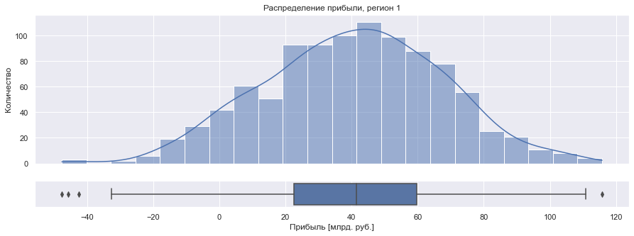

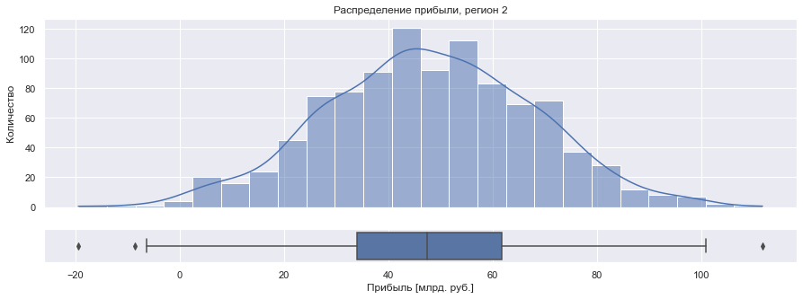

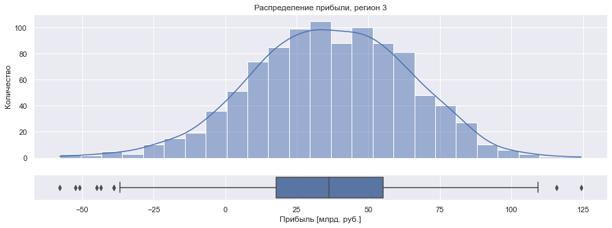

```python
profit_calc(results_1, 'product_pred', 'product', 1, 1000, 500, 200)
profit_calc(results_2, 'product_pred', 'product', 2, 1000, 500, 200)
profit_calc(results_3, 'product_pred', 'product', 3, 1000, 500, 200)
```

## Вывод по проекту

**Исходные данные:**

Представленные данные высокого качества и не имеют особых проблем. Признаки для обучающей выборки имеют схожий масштаб.

Во втором регионе данные практически равномерно распределены по 12 уникальным значениям product. Такое впечатление, что эти данные просто взяты равномерно по каким-то 12 категориям табличных значений. Возможно именно с этим связана дискретность признака f2, который, вероятно, уникализирован в небольшом пределе рандомно.

**Итоги валидации моделей линейной регрессии:**

Регион 1:

- Скор R2 модели региона 1 при кросс-валидации == 0.277
- RMSE модели региона 1 на валидационной выборке == 37.761
- Cредний запас предсказанного сырья региона 1 == 92.287

Для региона 1 мы получили достаточно низкий показатель R2 примерно 0,28. Такой коэффичиент детерминации означает, что имеющиеся у нас значения неслишком хорошо коррелируют с нашей линей моделью. Это в принципе подтверждает сделанные нами ранее выводы. RMSE 37,76 так же достаточно большой для полученного среднего 92.287. Однако среднее значение предсказано достаточно точно.

Регион 2:

По региону 2 мы получили великолепный показатель R2 практически 1. Такой коэффициент детерминации означает, что наша модель практически идеально описывает распределение значений и имеет очень высокую точность предсказаний. RMSE 0,89 так же отличный для полученного среднего 69.17. Данные выглядят синтетическими и неправдоподобными. Необходимо обратить на это внимание заказчика.

Регион 3:

- Скор R2 модели региона 3 при кросс-валидации == 0.2
- RMSE модели региона 3 на валидационной выборке == 40.131
- Cредний запас предсказанного сырья региона 3 == 94.821

Для региона 3 мы получили низкий показатель R2 примерно 0,2, что даже ниже, чем в 1 регионе. Линейная корреляция значений еще ниже, чем в регионе 1, что так же подтвеждает наши предыдущие выводы. RMSE 40,13 так же достаточно большой для полученного среднего 94.821. Средние запасы предсказаны максимальные в регионе 3.

**Точка безубыточности добычи:**

Минимальный суммарный запас сырья в регионе для окупаемости == 22222.22 тыс. баррелей Минимальный суммарный запас сырья на скважину для окупаемости (по 200 скважинам) == 111.11 тыс. баррелей

**Результаты расчетов по регионам:**

```python
profit_calc(results_1, 'product_pred', 'product', 1, 1000, 500, 200)
profit_calc(results_2, 'product_pred', 'product', 2, 1000, 500, 200)
profit_calc(results_3, 'product_pred', 'product', 3, 1000, 500, 200)
```

[output not shown]